# Gestion des données d’inventaires d’arbres - Afrique centrale

2019-01-21

## Petit historique / contexte Afrique centrale

- **2005** le Missouri Botanical Garden commence à réaliser des inventaires d’arbres au Gabon. Inventaires de type ‘Gentry’ : 4 tronçons de 50x25 m, mesures DBH et identification des arbres > 5 cm DBH.
- **2007** Début de ma thèse, je reprend cette méthodologie -> accumulation des données -> Base de données ACCESS pour faciliter leur gestion.
- **2011** Premières parcelles permanentes 1 ha de l’AMAP au Cameroun. Problématique de standardisation taxonomique -> importation dans la BDD Access.

## Petit historique / contexte Afrique centrale

- **2012** Dans un souci d'homogénéisation et de pérénnisation des données, importation d’autres inventaires d’Afrique centrale (ex: parcelles de 0.4 ha de Bruno Senterre en Guinée Equatoriale, transects de Jean-François Gillet au Gabon et Congo, etc…).

```
##                  method   n
## 1           0.1 ha plot 147
## 2             1 ha plot  15
## 3               1ha-IRD 152
## 4            50 ha CTFS  51
## 5                 Large 296
## 6      Layon J-F Gillet  87
## 7  Layon_Lejoly_10cmDBH  85
## 8            Plot_40x40  18
## 9       Relevé Senterre  37
## 10                Small 100
```

- **2018** >900 inventaires >190 000 arbres

## Problèmes

- BDD access peu élaborée.
- Accumulation continue de données, mises à jour régulières, demandes d'exportations…

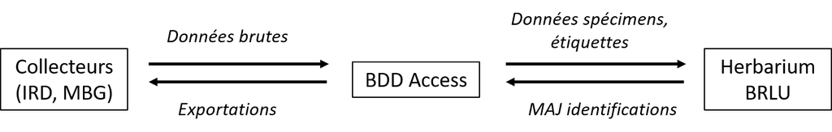

- Peu de visibilité (même en interne!) sur l'existant.
- **Besoin de procédures plus efficaces pour faciliter la manipulation des données, la rendre accessible à d'autres et faire en sorte que tout le monde travaille sur une même version.**

## Solution proposée

- BDD sous **format postgreSQL**.
- Gestion sous **R** en utilisant essentiellement les packages **DBI** et **dplyr**. Allie la rapidité du SQL à la souplesse de R. Les données ne sont pas chargées sur R -> mémoire RAM épargnée.
- Manipulation via (1) **fonctions R** ou (2) **applications WEB** shiny.
- **Partage** sous forme de package R.
- Code partagé sous **github** –> développement collaboratif, visibilité et prise en main par d'autres.

## Structure postgreSQL

Base de données relationelles

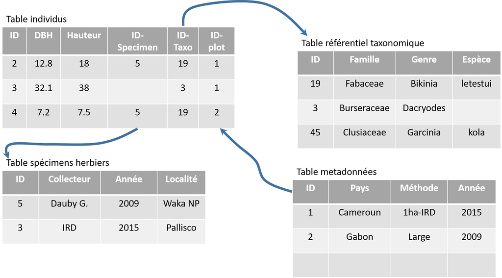

## Archivage des modifications

Pour toutes modifications, les lignes modifiées sont archivés dans une table analogue.

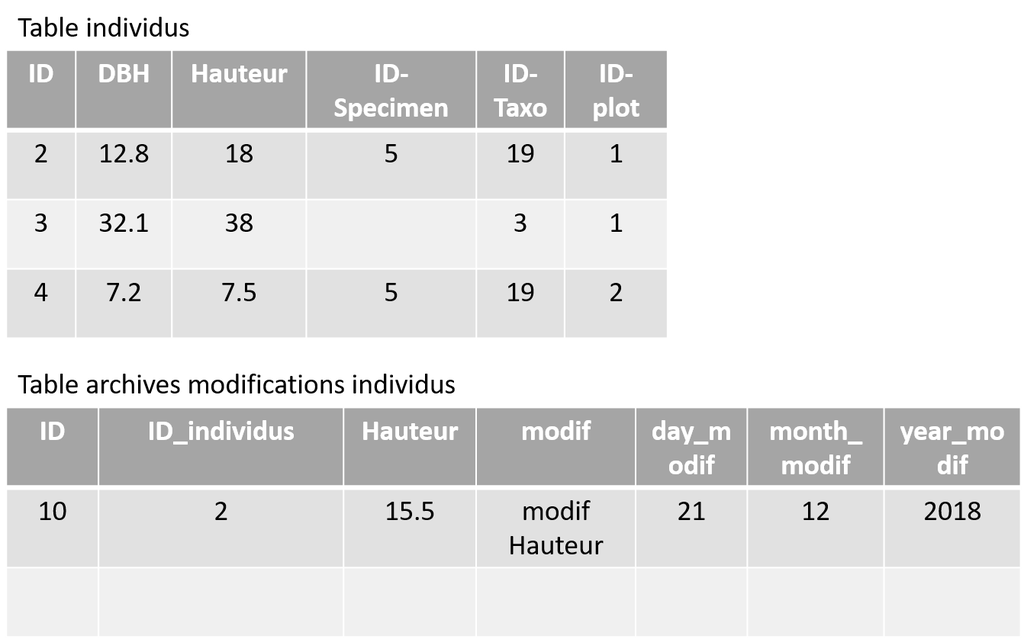

## Exemples de fonctions

- Extraction et visualisation des tables.

```r
query_plots() ### extraction/visualisation et mapping des données de plots

query_specimens() ### extraction/visualisation des données d'herbiers - génération d'étiquettes

query_tax_all() ### extraction/visualisation des données taxonomiques


query_specimens(collector = "MBG", number = 204)
```

## Cartographie

```r
query_plots(country = "Gabon", method = "IRD", map = TRUE)
```

[interactive chart not shown]

## Génération d'étiquettes d'herbiers

```r
query_specimens(collector = "IRD", number_min = 100, number_max = 200,
                generate_labels = TRUE, file_labels = "exemple_ird_labels")
```

```
## # A tibble: 101 x 21
##    colnam colnbr suffix full_name tax_fam tax_gen tax_esp ddlat   ddlon
##    <chr>   <int> <chr>  <chr>     <chr>   <chr>   <chr>   <dbl>   <dbl>
##  1 IRD       100 <NA>   Diospyro~ Ebenac~ Diospy~ cinnab~ 10.6   -0.714
##  2 IRD       131 <NA>   Lepidobo~ Lepido~ Lepido~ staudt~  3.30  13.8
##  3 IRD       132 <NA>   Balanite~ Zygoph~ Balani~ wilson~  3.30  13.8
##  4 IRD       128 <NA>   Dialium ~ Caesal~ Dialium angole~  3.30  13.8
##  5 IRD       143 <NA>   Maesobot~ Phylla~ Maesob~ klaine~  3.30  13.8
##  6 IRD       127 <NA>   Drypetes  Putran~ Drypet~ <NA>     3.30  13.8
##  7 IRD       163 <NA>   Uvariast~ Annona~ Uvaria~ pierre~  3.30  13.8
##  8 IRD       164 <NA>   Desborde~ Irving~ Desbor~ insign~  3.30  13.8
##  9 IRD       174 <NA>   Drypetes~ Putran~ Drypet~ lacini~  3.30  13.8
## 10 IRD       179 <NA>   Trichosc~ Anacar~ Tricho~ <NA>     3.30  13.8
## # ... with 91 more rows, and 12 more variables: country <chr>,
## #   detby <chr>, detd <int>, detm <int>, dety <int>, add_col <chr>,
## #   cold <int>, colm <int>, coly <int>, detvalue <int>, id_specimen <int>,
## #   id_diconame_n <int>
```

## Exemples de fonctions

- Ajout de données

```r
add_entry_dico_name() ### ajout de taxa

add_individuals() ### ajout d'individus

add_plots() ### ajout de métadonnées
```

- Mise à jour des données

```r
update_dico_name() ### Mise à jour du référentiel taxo

update_ident_specimens() ### Mise à jour de la table des spécimens

update_plot_data() ### Mise à jour des meta-données

update_individuals() ### Mise à jour de la table individus
```

## Applications

- Exemples d'applications web pour les allergiques à R.

```r
launch_query_tax_app() ### Lance une appli pour explorer les données de taxa



launch_stand_tax_app() ### Module pour standardiser la taxonomie - étape préalable à l'ajout de données
```

## Conclusions et perspectives

- Encore à faire (données de traits, remesures des parcelles IRD, visualisation intra-parcelle) mais fonctionnel en local.
- Objectif de faciliter la manipulation de la BDD atteint (pour moi).
- Partage -> OK

  **si la BDD postgreSQL est déposé sur un serveur IRD (machine virtuelle)**.
- Reprise en main du code possible.

## Conclusions et perspectives

- Transfert à d'autres jeux de données d'inventaires. Possible mais nécessite travail d'optimisation et d'adaptation du code.
- Se coordonner avec les développeurs d'applications Android pour faciliter l'acquisition de données de plots au Cameroun.
- Licence, contrat d'utilisation, convention de partage de données (ULB, MBG).
- Commentaires, critiques, suggestions ?